# Customer Churn Prediction with Machine Learning

Hai Pham

9/25/2020

## 1. Load the dataset and package

```r
library (ggplot2)
library(reshape2)
library(glmnet)
library(plotmo)
library(dplyr)
library(tidyverse)
library(caret)
tele_data = read.csv('C:/Users/Hai Pham/Google Drive/MBA journey/Notre Dame/Classes/Second Year/Mod 1/Machine Learning/Project/Selected Dataset/Orange Telecom dataset.csv')
```

## 2. Data Exploration

First let’s take a look at the top, bottom and dimension, and summary of the dataset

```r
head(tele_data)
```

```
##   State Account.length Area.code International.plan Voice.mail.plan
## 1    KS            128       415                 No             Yes
## 2    OH            107       415                 No             Yes
## 3    NJ            137       415                 No              No
## 4    OH             84       408                Yes              No
## 5    OK             75       415                Yes              No
## 6    AL            118       510                Yes              No
##   Number.vmail.messages Total.day.minutes Total.day.calls Total.day.charge
## 1                    25             265.1             110            45.07
## 2                    26             161.6             123            27.47
## 3                     0             243.4             114            41.38
## 4                     0             299.4              71            50.90
## 5                     0             166.7             113            28.34
## 6                     0             223.4              98            37.98
##   Total.eve.minutes Total.eve.calls Total.eve.charge Total.night.minutes
```

[output cut: 20 more lines]

```r
tail(tele_data)
```

```
##      State Account.length Area.code International.plan Voice.mail.plan
## 3328    CA             84       415                 No              No
## 3329    WI            114       415                 No             Yes
## 3330    AL            106       408                 No             Yes
## 3331    VT             60       415                 No              No
## 3332    WV            159       415                 No              No
## 3333    CT            184       510                Yes              No
##      Number.vmail.messages Total.day.minutes Total.day.calls Total.day.charge
## 3328                     0             280.0             113            47.60
## 3329                    26             137.1              88            23.31
## 3330                    29              83.6             131            14.21
## 3331                     0             193.9             118            32.96
## 3332                     0             169.8             114            28.87
## 3333                     0             213.8             105            36.35
##      Total.eve.minutes Total.eve.calls Total.eve.charge Total.night.minutes
```

[output cut: 20 more lines]

```r
dim(tele_data)
```

```
## [1] 3333   20
```

```r
summary(tele_data)
```

```
##      State      Account.length    Area.code     International.plan
##  WV     : 106   Min.   :  1.0   Min.   :408.0   No :3010
##  MN     :  84   1st Qu.: 74.0   1st Qu.:408.0   Yes: 323
##  NY     :  83   Median :101.0   Median :415.0
##  AL     :  80   Mean   :101.1   Mean   :437.2
##  OH     :  78   3rd Qu.:127.0   3rd Qu.:510.0
##  OR     :  78   Max.   :243.0   Max.   :510.0
##  (Other):2824
##  Voice.mail.plan Number.vmail.messages Total.day.minutes Total.day.calls
##  No :2411        Min.   : 0.000        Min.   :  0.0     Min.   :  0.0
##  Yes: 922        1st Qu.: 0.000        1st Qu.:143.7     1st Qu.: 87.0
##                  Median : 0.000        Median :179.4     Median :101.0
##                  Mean   : 8.099        Mean   :179.8     Mean   :100.4
##                  3rd Qu.:20.000        3rd Qu.:216.4     3rd Qu.:114.0
##                  Max.   :51.000        Max.   :350.8     Max.   :165.0
##
##  Total.day.charge Total.eve.minutes Total.eve.calls Total.eve.charge
##  Min.   : 0.00    Min.   :  0.0     Min.   :  0.0   Min.   : 0.00
##  1st Qu.:24.43    1st Qu.:166.6     1st Qu.: 87.0   1st Qu.:14.16
##  Median :30.50    Median :201.4     Median :100.0   Median :17.12
##  Mean   :30.56    Mean   :201.0     Mean   :100.1   Mean   :17.08
##  3rd Qu.:36.79    3rd Qu.:235.3     3rd Qu.:114.0   3rd Qu.:20.00
##  Max.   :59.64    Max.   :363.7     Max.   :170.0   Max.   :30.91
##
##  Total.night.minutes Total.night.calls Total.night.charge Total.intl.minutes
##  Min.   : 23.2       Min.   : 33.0     Min.   : 1.040     Min.   : 0.00
##  1st Qu.:167.0       1st Qu.: 87.0     1st Qu.: 7.520     1st Qu.: 8.50
##  Median :201.2       Median :100.0     Median : 9.050     Median :10.30
##  Mean   :200.9       Mean   :100.1     Mean   : 9.039     Mean   :10.24
##  3rd Qu.:235.3       3rd Qu.:113.0     3rd Qu.:10.590     3rd Qu.:12.10
##  Max.   :395.0       Max.   :175.0     Max.   :17.770     Max.   :20.00
##
##  Total.intl.calls Total.intl.charge Customer.service.calls Churn
##  Min.   : 0.000   Min.   :0.000     Min.   :0.000          No :2850
##  1st Qu.: 3.000   1st Qu.:2.300     1st Qu.:1.000          Yes: 483
##  Median : 4.000   Median :2.780     Median :1.000
##  Mean   : 4.479   Mean   :2.765     Mean   :1.563
##  3rd Qu.: 6.000   3rd Qu.:3.270     3rd Qu.:2.000
##  Max.   :20.000   Max.   :5.400     Max.   :9.000
##
```

```r
str(tele_data)
```

```
## 'data.frame':    3333 obs. of  20 variables:
##  $ State                 : Factor w/ 51 levels "AK","AL","AR",..: 17 36 32 36 37 2 20 25 50 40 ...
##  $ Account.length        : int  128 107 137 84 75 118 121 147 141 74 ...
##  $ Area.code             : int  415 415 415 408 415 510 510 415 415 415 ...
##  $ International.plan    : Factor w/ 2 levels "No","Yes": 1 1 1 2 2 2 1 2 2 1 ...
##  $ Voice.mail.plan       : Factor w/ 2 levels "No","Yes": 2 2 1 1 1 1 2 1 2 1 ...
##  $ Number.vmail.messages : int  25 26 0 0 0 0 24 0 37 0 ...
##  $ Total.day.minutes     : num  265 162 243 299 167 ...
##  $ Total.day.calls       : int  110 123 114 71 113 98 88 79 84 127 ...
##  $ Total.day.charge      : num  45.1 27.5 41.4 50.9 28.3 ...
##  $ Total.eve.minutes     : num  197.4 195.5 121.2 61.9 148.3 ...
##  $ Total.eve.calls       : int  99 103 110 88 122 101 108 94 111 148 ...
##  $ Total.eve.charge      : num  16.78 16.62 10.3 5.26 12.61 ...
##  $ Total.night.minutes   : num  245 254 163 197 187 ...
##  $ Total.night.calls     : int  91 103 104 89 121 118 118 96 97 94 ...
##  $ Total.night.charge    : num  11.01 11.45 7.32 8.86 8.41 ...
##  $ Total.intl.minutes    : num  10 13.7 12.2 6.6 10.1 6.3 7.5 7.1 11.2 9.1 ...
##  $ Total.intl.calls      : int  3 3 5 7 3 6 7 6 5 5 ...
##  $ Total.intl.charge     : num  2.7 3.7 3.29 1.78 2.73 1.7 2.03 1.92 3.02 2.46 ...
##  $ Customer.service.calls: int  1 1 0 2 3 0 3 0 0 0 ...
##  $ Churn                 : Factor w/ 2 levels "No","Yes": 1 1 1 1 1 1 1 1 1 1 ...
```

The dataset used for this project includes customers’ usage data of a telecomcomunications company, Orange S.A. (“Orange”), and is publicly available on Kaggle. The dataset consists of 3,333 observations, each of which describes features of a unique customer. There are 20 variables, 19 of which are customers’ demographic and usage data and 1 churn label specifying whether a customer continues or discontinues Orange ’s services.

- State: 51 states in the US
- Account.length: number of days from account opening to data collection time, ranging from 1 to 243 days
- Area.code: 415 relates to San Francisco, 408 is of San Jose and 510 is of City of Oakland
- International.plan: Yes indicates that international plan is present and No indicates no subscription for intertional plan
- Voice.mail.plan: Yes indicates that voice mail plan is present and No indicates no subscription for voice mail plan
- Number.vmail.messages: number of voice mail messages
- Total.day.minutes: total number of minutes spent by customer in morning and afternoon
- Total.day.calls: total number of calls made by customer in morning and afternoon
- Total.day.charge: total charge to the customer in morning and afternoon
- Total.eve.minutes: total number of minutes spent by customer in evening
- Total.eve.calls: total number of calls made by customer in evening
- Total.eve.charge: total charge to the customer in evening
- Total.night.minutes: total number of minutes spent by customer in night
- Total.night.calls: total number of calls made by customer in night
- Total.night.charge: total charge to the customer in night
- Total.intl.minutes: total number of minutes spent by customer on international calls
- Total.intl.calls: total number of international calls made by customer
- Total.intl.charge: total charge to the customer for international calls
- Customer.service.calls: total number of customer services calls made by customer
- Churn: Yes indicates that customer cancel the subscription while No indicates that customer continue services.There are 2,850 customers in this dataset continuing Orange’s service and 483 people churn

Now let’s check to see if we have any missing values in the dataset.

```r
sum(is.na(tele_data))
```

```
## [1] 0
```

We can see that this is a cleaned dataset without missing values.

## 3. Preliminary Data Analysis

Based upon the summary function above, we conclude that State and Area code are identifiers and thus have no explanatory power. Churn would be the response variable and the other 17 variables are explanatory variables.

First let’s visualize the response variable

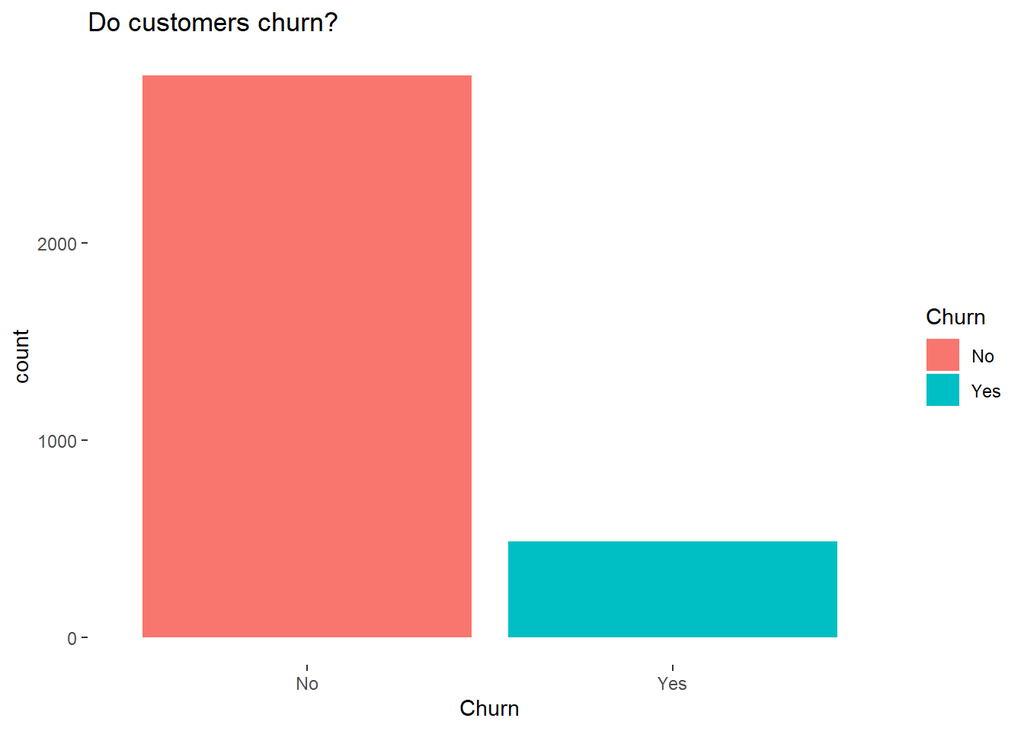

```r
tele_data %>% ggplot(aes(x = Churn, fill = Churn)) +
              geom_bar() +
              theme_set(theme_bw(base_size = 22) ) +
              theme(panel.grid.major = element_blank(),
              panel.grid.minor = element_blank(),
              panel.border = element_blank(),
              panel.background = element_blank() ) +
              labs(title = "Do customers churn?",
                   fill = "Churn")
```

We can tell that this is an imbalanced dataset with 2,850 No values and 483 Yes values in response variable

As a preliminary analysis we can visualize how features vary for customers that continue and discontinue services.

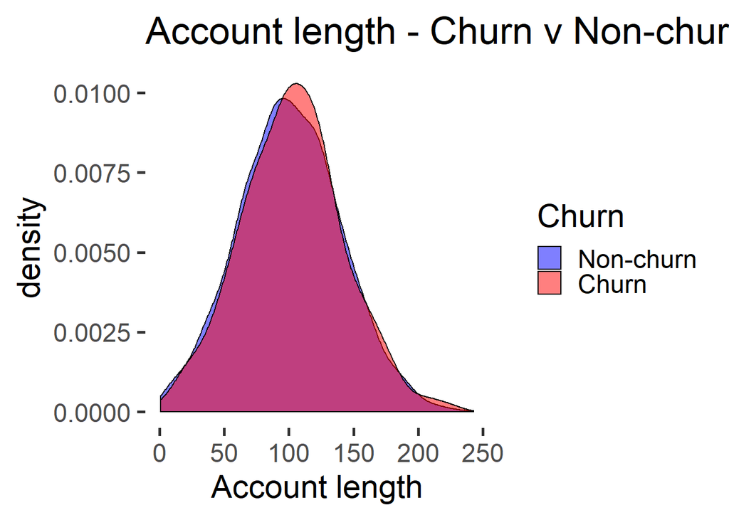

```r
plot_dat <- tele_data
plot_dat$Churn <- as.factor(plot_dat$Churn)
g_1 <- ggplot(plot_dat, aes(x = Account.length, fill = Churn)) +
  geom_density(alpha = 0.5) +
    theme_set(theme_bw(base_size = 22) ) +
  theme(panel.grid.major = element_blank(),
        panel.grid.minor = element_blank(),
        panel.border = element_blank(),
        panel.background = element_blank()) +
  labs(x = "Account length", title = "Account length - Churn v Non-churn",
       fill = "Churn") +
  scale_fill_manual(values = c("Yes" = "red", "No" = "blue"),
                    labels = c("Yes" = "Churn", "No" = "Non-churn"))
g_1
```

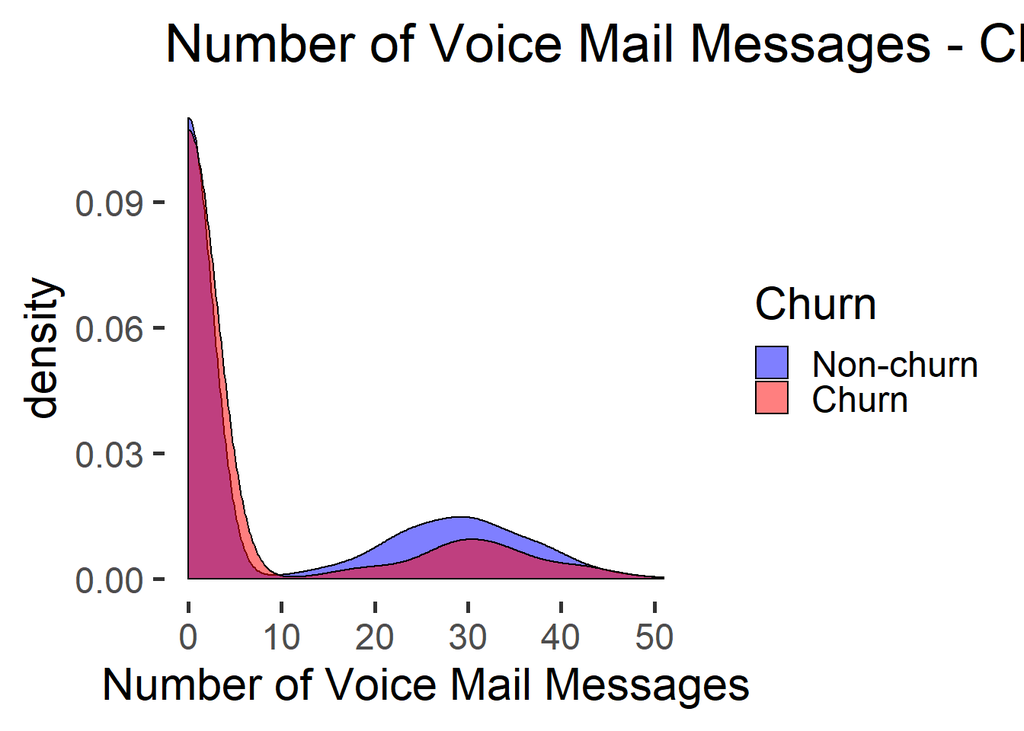

```r
g_2 <- ggplot(plot_dat, aes(x = Number.vmail.messages, fill = Churn)) +
  geom_density(alpha = 0.5) +
    theme_set(theme_bw(base_size = 22) ) +
  theme(panel.grid.major = element_blank(),
        panel.grid.minor = element_blank(),
        panel.border = element_blank(),
        panel.background = element_blank()) +
  labs(x = "Number of Voice Mail Messages", title = "Number of Voice Mail Messages - Churn v Non-churn",
       fill = "Churn") +
  scale_fill_manual(values = c("Yes" = "red", "No" = "blue"),
                    labels = c("Yes" = "Churn", "No" = "Non-churn"))
g_2
```

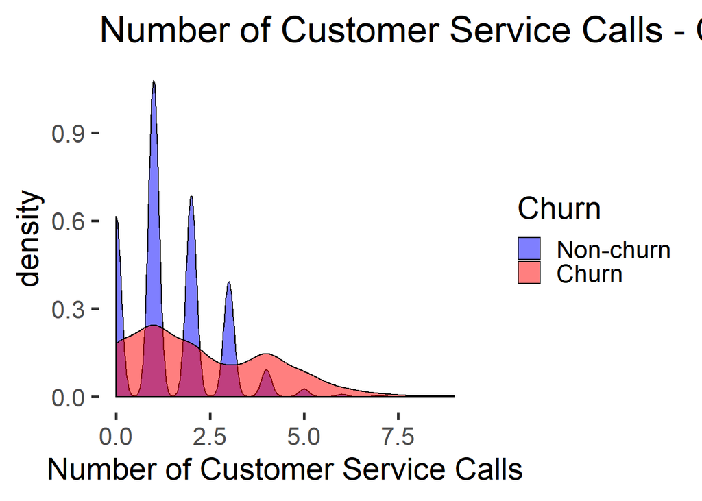

```r
g_3 <- ggplot(plot_dat, aes(x = Customer.service.calls, fill = Churn)) +
  geom_density(alpha = 0.5) +
    theme_set(theme_bw(base_size = 22) ) +
  theme(panel.grid.major = element_blank(),
        panel.grid.minor = element_blank(),
        panel.border = element_blank(),
        panel.background = element_blank()) +
  labs(x = "Number of Customer Service Calls", title = "Number of Customer Service Calls - Churn v Non-churn",
       fill = "Churn") +
  scale_fill_manual(values = c("Yes" = "red", "No" = "blue"),
                    labels = c("Yes" = "Churn", "No" = "Non-churn"))
g_3
```

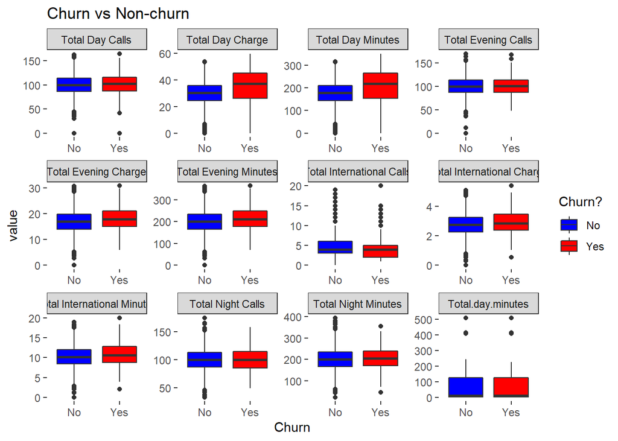

```r
m_dat <- melt(plot_dat, is.vars = "Churn")
m_dat$var_2 <- rep("Total.day.minutes", nrow(m_dat))
m_dat$var_2[which(m_dat$variable == "Total.day.minutes")] <- "Total Day Minutes"
m_dat$var_2[which(m_dat$variable == "Total.day.calls")] <- "Total Day Calls"
m_dat$var_2[which(m_dat$variable == "Total.day.charge")] <- "Total Day Charge"
m_dat$var_2[which(m_dat$variable == "Total.eve.minutes")] <- "Total Evening Minutes"
m_dat$var_2[which(m_dat$variable == "Total.eve.calls")] <- "Total Evening Calls"
m_dat$var_2[which(m_dat$variable == "Total.eve.charge")] <- "Total Evening Charge"
m_dat$var_2[which(m_dat$variable == "Total.night.minutes")] <- "Total Night Minutes"
m_dat$var_2[which(m_dat$variable == "Total.night.calls")] <- "Total Night Calls"
m_dat$var_2[which(m_dat$variable == "Total.night.charges")] <- "Total Night Charge"
m_dat$var_2[which(m_dat$variable == "Total.intl.minutes")] <- "Total International Minutes"
m_dat$var_2[which(m_dat$variable == "Total.intl.calls")] <- "Total International Calls"
m_dat$var_2[which(m_dat$variable == "Total.intl.charge")] <- "Total International Charge"

g_4 <- ggplot(m_dat, aes( y = value, x = Churn, fill = Churn)) +
  geom_boxplot() +
  facet_wrap(~var_2, scales = "free") +
    theme_bw() +
  theme(panel.grid.major = element_blank(),
        panel.grid.minor = element_blank(),
        panel.border = element_blank(),
        panel.background = element_blank()) +
  labs(x = "Churn", title = "Churn vs Non-churn",
       fill = "Churn?") +
  scale_fill_manual(values = c("Yes" = "red", "No" = "blue"),
                    labels = c("Yes" = "Yes", "No" = "No"))
g_4
```

The above boxplots show that Total Day Charge, Total Day Minutes, Total Evening Charge, Total Evening Minutes of customers churning service tend to be higher than those of customer continuing services.

## 4. Model Development

Remove 2 variables *State* and *Area.code* which have no predictive power in the model. Also, the *Churn* variable should be converted to factor format.

```r
tele_data <- tele_data %>% select( -"State", -"Area.code")
tele_data$Churn = as.factor(tele_data$Churn)
```

Split the data into train/test sets with 80% of observations for train dataset and 20% of observations for test dataset.

```r
set.seed(101)
sample = sample.int(n = nrow(tele_data), size = floor(.8*nrow(tele_data)), replace = FALSE)
train = tele_data[sample, ]
test = tele_data[-sample, ]
```

Developing Logistic Regression using train dataset

```r
fit_total <- glm(Churn ~ .,
             family=binomial(link='logit'),
             data= train)
summary(fit_total)
```

```
##
## Call:
## glm(formula = Churn ~ ., family = binomial(link = "logit"), data = train)
##
## Deviance Residuals:
##     Min       1Q   Median       3Q      Max
## -2.0755  -0.5242  -0.3484  -0.2010   3.1586
##
## Coefficients:
##                          Estimate Std. Error z value Pr(>|z|)
## (Intercept)            -8.2261980  0.7952540 -10.344  < 2e-16 ***
## Account.length          0.0015013  0.0015488   0.969 0.332390
## International.planYes   1.9618224  0.1611977  12.170  < 2e-16 ***
## Voice.mail.planYes     -1.8797415  0.6552470  -2.869 0.004121 **
## Number.vmail.messages   0.0319078  0.0205990   1.549 0.121382
## Total.day.minutes       1.4654391  3.5926374   0.408 0.683347
## Total.day.calls         0.0022413  0.0030575   0.733 0.463541
## Total.day.charge       -8.5477165 21.1331954  -0.404 0.685868
## Total.eve.minutes      -0.1348344  1.7967357  -0.075 0.940180
## Total.eve.calls        -0.0007703  0.0031049  -0.248 0.804053
## Total.eve.charge        1.6665718 21.1378468   0.079 0.937157
## Total.night.minutes    -0.0850091  0.9695354  -0.088 0.930131
## Total.night.calls       0.0014995  0.0031708   0.473 0.636274
## Total.night.charge      1.9717053 21.5447016   0.092 0.927082
## Total.intl.minutes     -5.5789685  5.8363301  -0.956 0.339121
## Total.intl.calls       -0.0964818  0.0278337  -3.466 0.000528 ***
## Total.intl.charge      20.9805279 21.6163279   0.971 0.331754
## Customer.service.calls  0.5035531  0.0433353  11.620  < 2e-16 ***
## ---
## Signif. codes:  0 '***' 0.001 '**' 0.01 '*' 0.05 '.' 0.1 ' ' 1
##
## (Dispersion parameter for binomial family taken to be 1)
##
##     Null deviance: 2226.3  on 2665  degrees of freedom
## Residual deviance: 1764.4  on 2648  degrees of freedom
## AIC: 1800.4
##
## Number of Fisher Scoring iterations: 6
```

Based on the above output, we see that there are only 4 coefficients that are statistically different from 0. They are *International.plan*, *Voice.mail.plan*, *Total.intl.calls* , and *Customer.service.calls*. Let’s try including only variables that have p-values that are lower than 0.05

```r
fit_total1 <- glm(Churn ~ International.plan + Voice.mail.plan + Total.intl.calls + Customer.service.calls,
             family=binomial(link='logit'),
             data= train)
summary(fit_total1)
```

```
##
## Call:
## glm(formula = Churn ~ International.plan + Voice.mail.plan +
##     Total.intl.calls + Customer.service.calls, family = binomial(link = "logit"),
##     data = train)
##
## Deviance Residuals:
##     Min       1Q   Median       3Q      Max
## -1.6400  -0.5438  -0.4244  -0.3064   2.7321
##
## Coefficients:
##                        Estimate Std. Error z value Pr(>|z|)
## (Intercept)            -2.34019    0.15493 -15.105  < 2e-16 ***
## International.planYes   1.91645    0.15157  12.644  < 2e-16 ***
## Voice.mail.planYes     -0.83168    0.15303  -5.435 5.49e-08 ***
## Total.intl.calls       -0.07660    0.02609  -2.936  0.00332 **
## Customer.service.calls  0.44328    0.04051  10.944  < 2e-16 ***
## ---
## Signif. codes:  0 '***' 0.001 '**' 0.01 '*' 0.05 '.' 0.1 ' ' 1
##
## (Dispersion parameter for binomial family taken to be 1)
##
##     Null deviance: 2226.3  on 2665  degrees of freedom
## Residual deviance: 1932.4  on 2661  degrees of freedom
## AIC: 1942.4
##
## Number of Fisher Scoring iterations: 5
```

The new model have a higher AIC than the first one. The first model with all variables would perform better and is thus selected as the final model

## 5. Model Performance Evaluation

Now let’s evaluate the model performance by running the training model against the test set and take a look at confusion matrix.

```r
test.probs <-predict(fit_total, test, type='response')
pred.logit <- rep('No',length(test.probs))
pred.logit[test.probs>=0.5] <- 'Yes'

table(pred.logit, test$Churn)
```

```
##
## pred.logit  No Yes
##        No  564  69
##        Yes  12  22
```

```r
confusionMatrix(test$Churn, as.factor(pred.logit))
```

```
## Confusion Matrix and Statistics
##
##           Reference
## Prediction  No Yes
##        No  564  12
##        Yes  69  22
##
##                Accuracy : 0.8786
##                  95% CI : (0.8513, 0.9024)
##     No Information Rate : 0.949
##     P-Value [Acc > NIR] : 1
##
##                   Kappa : 0.3001
##
##  Mcnemar's Test P-Value : 4.902e-10
##
##             Sensitivity : 0.8910
##             Specificity : 0.6471
##          Pos Pred Value : 0.9792
##          Neg Pred Value : 0.2418
##              Prevalence : 0.9490
##          Detection Rate : 0.8456
##    Detection Prevalence : 0.8636
##       Balanced Accuracy : 0.7690
##
##        'Positive' Class : No
##
```

We see that our model achieves a pretty good accuracy rate of 87.9%.

## 6. Insights generated from the Model

From the logistic regression model, we see that there are 4 variables that can help explain the response variable. Let’s do some visualization to get a better understanding of their relationships.

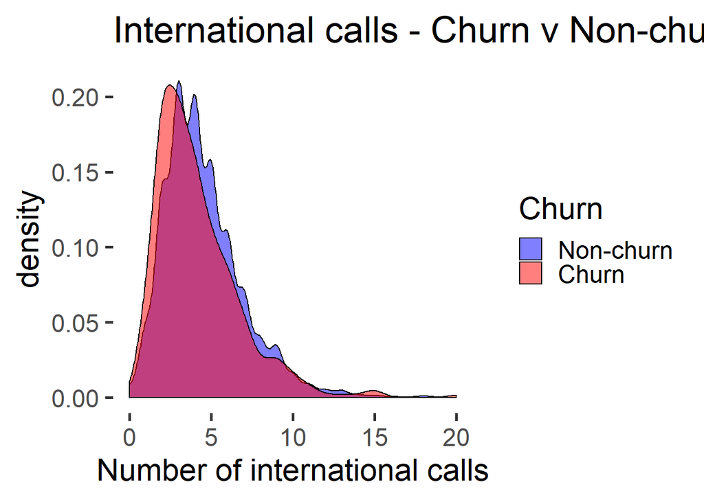

```r
g_5 <- ggplot(plot_dat, aes(x = Total.intl.calls, fill = Churn)) +
  geom_density(alpha = 0.5) +
    theme_set(theme_bw(base_size = 22) ) +
  theme(panel.grid.major = element_blank(),
        panel.grid.minor = element_blank(),
        panel.border = element_blank(),
        panel.background = element_blank()) +
  labs(x = "Number of international calls", title = "International calls - Churn v Non-churn",
       fill = "Churn") +
  scale_fill_manual(values = c("Yes" = "red", "No" = "blue"),
                    labels = c("Yes" = "Churn", "No" = "Non-churn"))
g_5
```

Customers that have low number of international calls are more likely to discontinue services.

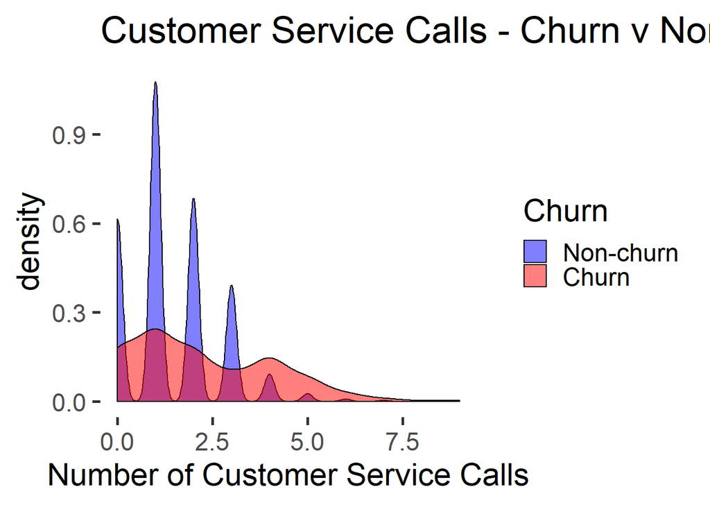

```r
g_6 <- ggplot(plot_dat, aes(x = Customer.service.calls, fill = Churn)) +
  geom_density(alpha = 0.5) +
    theme_set(theme_bw(base_size = 16) ) +
  theme(panel.grid.major = element_blank(),
        panel.grid.minor = element_blank(),
        panel.border = element_blank(),
        panel.background = element_blank()) +
  labs(x = "Number of Customer Service Calls", title = "Customer Service Calls - Churn v Non-churn",
       fill = "Churn") +
  scale_fill_manual(values = c("Yes" = "red", "No" = "blue"),
                    labels = c("Yes" = "Churn", "No" = "Non-churn"))
g_6
```

Customers that have high number of customer service calls are more likely to discontinue services.

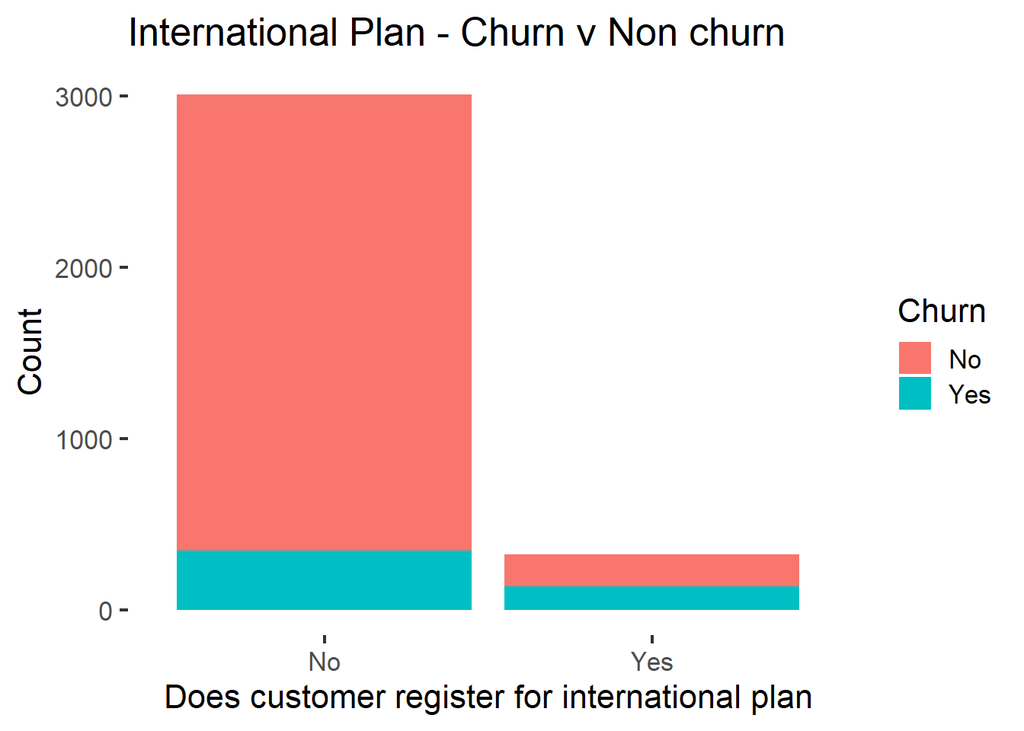

```r
dat1 = data.frame(table(tele_data$International.plan, tele_data$Churn))
names(dat1) = c("InternationalPlan", "Churn", "Count")

ggplot(data=dat1, aes(x=InternationalPlan, y=Count, fill=Churn )) + geom_bar(stat="identity") +
    theme_set(theme_bw(base_size = 16) ) +
  theme(panel.grid.major = element_blank(),
        panel.grid.minor = element_blank(),
        panel.border = element_blank(),
        panel.background = element_blank())  +
  labs(x = "Does customer register for international plan", title = "International Plan - Churn v Non churn",
       fill = "Churn")
```

[figure not shown]

```r
dat2 = data.frame(table(tele_data$Voice.mail.plan, tele_data$Churn))
names(dat1) = c("VoiceMailPlan", "Churn", "Count")

ggplot(data=dat1, aes(x=VoiceMailPlan, y=Count, fill=Churn )) + geom_bar(stat="identity") +
    theme_set(theme_bw(base_size = 16) ) +
  theme(panel.grid.major = element_blank(),
        panel.grid.minor = element_blank(),
        panel.border = element_blank(),
        panel.background = element_blank())  +
  labs(x = "Does customer register for voice mail plan", title = "Voice Mail Plan - Churn v Non churn",
       fill = "Churn")
```